# Regression models for paper - Breathing and speech adaptation

```r
summary(s1a <- lmer(articRateIPU ~ Task:Condition + (1+Task | Speaker), df))
```

```
## fixed-effect model matrix is rank deficient so dropping 1 column / coefficient
```

```
## Linear mixed model fit by REML ['lmerMod']
## Formula: articRateIPU ~ Task:Condition + (1 + Task | Speaker)
##    Data: df
##
## REML criterion at convergence: 10089.1
##
## Scaled residuals:
##     Min      1Q  Median      3Q     Max
## -4.1980 -0.5709 -0.0453  0.5418  5.6064
##
## Random effects:
##  Groups   Name          Variance Std.Dev. Corr
##  Speaker  (Intercept)   0.02375  0.1541
##           TaskReadJoint 0.01468  0.1212   -0.27
##  Residual               0.40546  0.6368
## Number of obs: 5160, groups:  Speaker, 21
##
## Fixed effects:
##                                Estimate Std. Error t value
## (Intercept)                    4.156297   0.040689 102.149
## TaskReadAlone:ConditionSitting 0.013461   0.041392   0.325
## TaskReadJoint:ConditionSitting 0.004496   0.028226   0.159
## TaskReadAlone:ConditionLight   0.042134   0.040820   1.032
## TaskReadJoint:ConditionLight   0.011081   0.025921   0.427
## TaskReadAlone:ConditionHeavy   0.072540   0.040776   1.779
##
## Correlation of Fixed Effects:
##             (Intr) TRA:CS TRJ:CS TRA:CL TRJ:CL
## TskRdAln:CS -0.455
## TskRdJnt:CS -0.267  0.263
## TskRdAln:CL -0.461  0.603  0.267
## TskRdJnt:CL -0.292  0.287  0.423  0.292
## TskRdAln:CH -0.462  0.602  0.267  0.616  0.292
## fit warnings:
## fixed-effect model matrix is rank deficient so dropping 1 column / coefficient
```

```r
summary(s1b <- lmer(articRateIPU ~ Task:Cond3 + (1+Task | Speaker), df))
```

```
## fixed-effect model matrix is rank deficient so dropping 1 column / coefficient
```

```
## Linear mixed model fit by REML ['lmerMod']
## Formula: articRateIPU ~ Task:Cond3 + (1 + Task | Speaker)
##    Data: df
##
## REML criterion at convergence: 10079.7
##
## Scaled residuals:
##     Min      1Q  Median      3Q     Max
## -4.2061 -0.5769 -0.0439  0.5386  5.5993
##
## Random effects:
##  Groups   Name          Variance Std.Dev. Corr
##  Speaker  (Intercept)   0.02374  0.1541
##           TaskReadJoint 0.01458  0.1208   -0.27
##  Residual               0.40538  0.6367
## Number of obs: 5160, groups:  Speaker, 21
##
## Fixed effects:
##                             Estimate Std. Error t value
## (Intercept)                4.1607768  0.0428352  97.135
## TaskReadAlone:Cond3Biking  0.0528848  0.0390190   1.355
## TaskReadJoint:Cond3Biking  0.0006079  0.0255687   0.024
## TaskReadAlone:Cond3Sitting 0.0090146  0.0434710   0.207
##
## Correlation of Fixed Effects:
##             (Intr) TRA:C3B TRJ:C3
## TskRdAl:C3B -0.566
## TskRdJn:C3B -0.446  0.490
## TskRdAl:C3S -0.507  0.705   0.439
## fit warnings:
## fixed-effect model matrix is rank deficient so dropping 1 column / coefficient
```

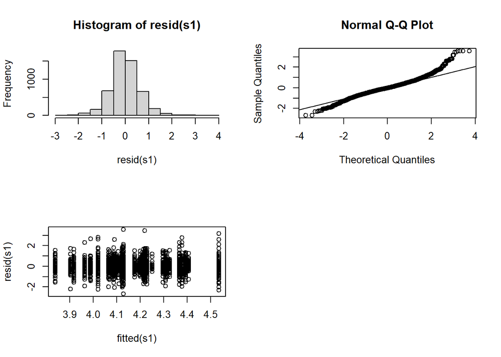

```r
par(mfrow=c(2, 2))
hist(resid(s1))
qqnorm(resid(s1));qqline(resid(s1))
plot(fitted(s1), resid(s1))

par(mfrow=c(2, 2))
```

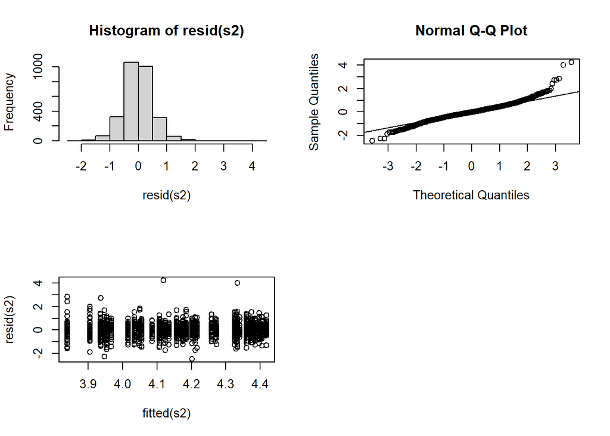

```r
hist(resid(s2))
qqnorm(resid(s2));qqline(resid(s2))
plot(fitted(s2), resid(s2))
```

# Breathing data during FREE speech

## Participants

### Breathing rate

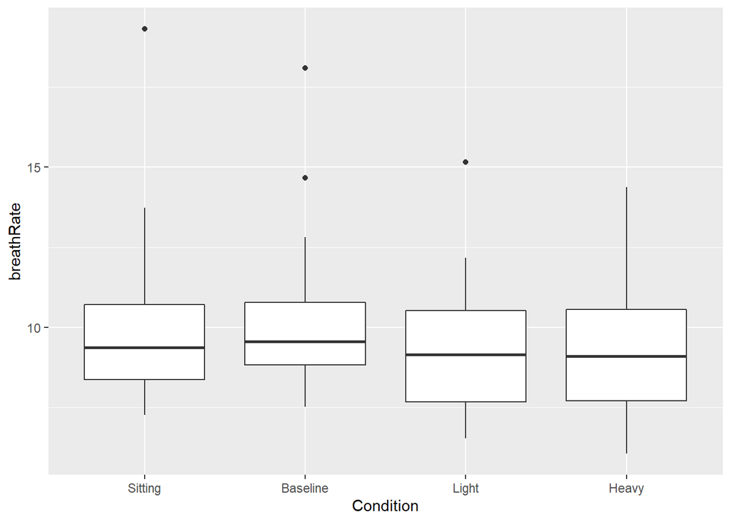

```r
ggplot(dat, aes(Condition, breathRate))+
  geom_boxplot()
```

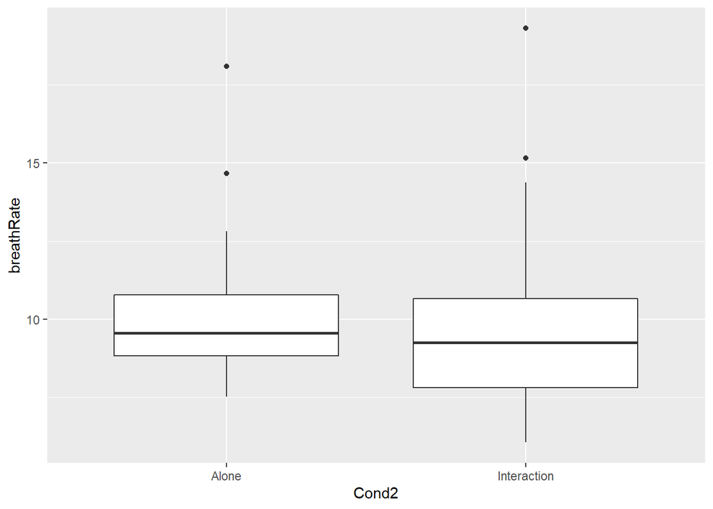

```r
ggplot(dat, aes(Cond2, breathRate))+
  geom_boxplot()
```

There is no significant difference in breathing rate between the conditions, *including no effect* between the baseline recording (`alone`) and the experimental conditions (`interaction`).

(There was only an effect when we used the z-scored breathing rate, but not with the actual values).

```r
summary(b1 <- lmer(breathRate ~ Condition + (1 | Speaker), dat))
```

```
## Linear mixed model fit by REML ['lmerMod']
## Formula: breathRate ~ Condition + (1 | Speaker)
##    Data: dat
##
## REML criterion at convergence: 369.1
##
## Scaled residuals:
##     Min      1Q  Median      3Q     Max
## -2.1184 -0.4590 -0.0460  0.4281  5.0761
##
## Random effects:
##  Groups   Name        Variance Std.Dev.
##  Speaker  (Intercept) 3.178    1.783
##  Residual             2.632    1.622
## Number of obs: 88, groups:  Speaker, 22
##
## Fixed effects:
##                   Estimate Std. Error t value
## (Intercept)         9.9836     0.5139  19.428
## ConditionBaseline   0.1604     0.4892   0.328
## ConditionLight     -0.6925     0.4892  -1.416
## ConditionHeavy     -0.6502     0.4892  -1.329
##
## Correlation of Fixed Effects:
##             (Intr) CndtnB CndtnL
## ConditnBsln -0.476
## ConditnLght -0.476  0.500
## ConditinHvy -0.476  0.500  0.500
```

```r
summary(b1a <- lmer(breathRate ~ Cond2 + (1 | Speaker), dat))
```

```
## Linear mixed model fit by REML ['lmerMod']
## Formula: breathRate ~ Cond2 + (1 | Speaker)
##    Data: dat
##
## REML criterion at convergence: 372.1
##
## Scaled residuals:
##     Min      1Q  Median      3Q     Max
## -2.2592 -0.4142 -0.0565  0.3621  5.3319
##
## Random effects:
##  Groups   Name        Variance Std.Dev.
##  Speaker  (Intercept) 3.172    1.781
##  Residual             2.653    1.629
## Number of obs: 88, groups:  Speaker, 22
##
## Fixed effects:
##                  Estimate Std. Error t value
## (Intercept)       10.1440     0.5146  19.713
## Cond2Interaction  -0.6079     0.4010  -1.516
##
## Correlation of Fixed Effects:
##             (Intr)
## Cnd2Intrctn -0.584
```

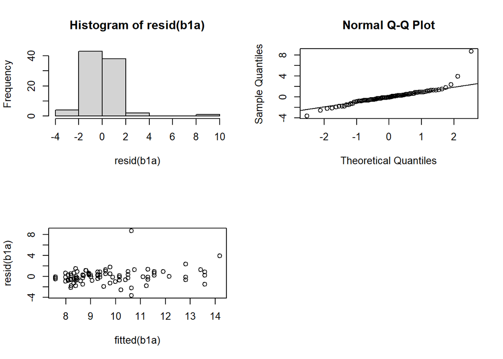

```r
par(mfrow=c(2, 2))
hist(resid(b1a))
qqnorm(resid(b1a));qqline(resid(b1a))
plot(fitted(b1a), resid(b1a))
```

### Breath cycle duration

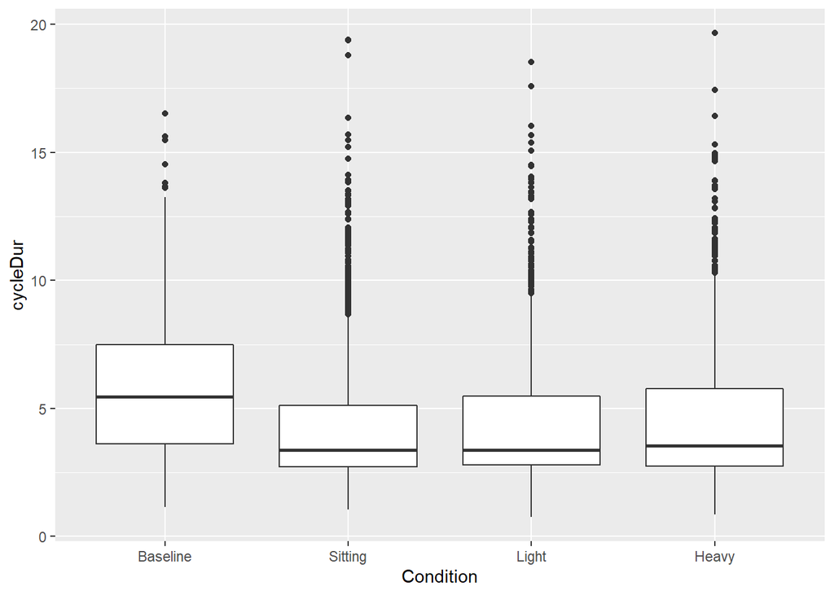

```r
ggplot(dat, aes(Condition, cycleDur))+
  geom_boxplot()+
  scale_x_discrete(limits = orderCondBase)
```

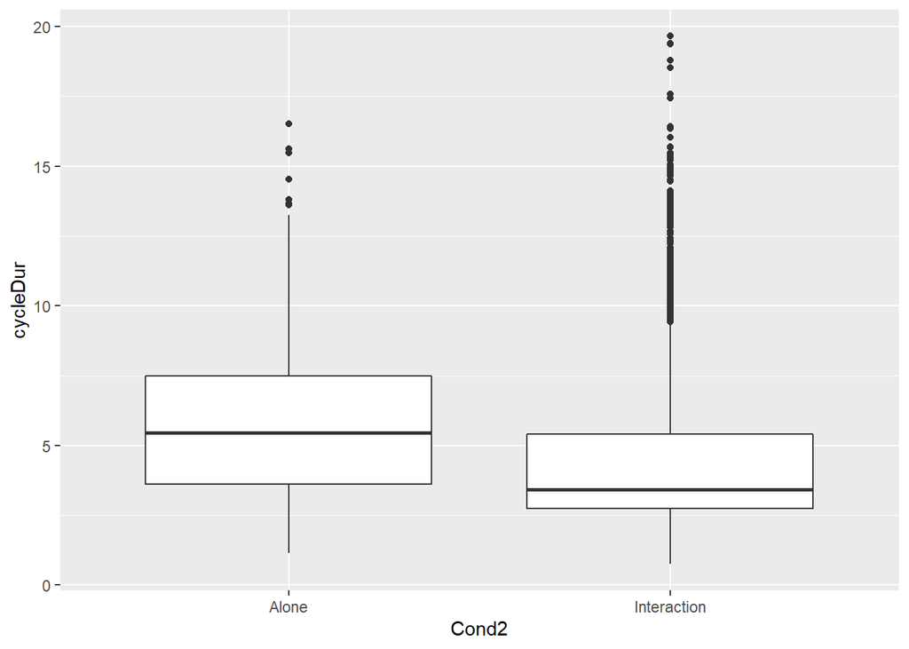

```r
ggplot(dat, aes(Cond2, cycleDur))+
  geom_boxplot()
```

- Cycles are longer during `baseline` (speaking alone) than during the `interaction`.
- Cycles are slightly longer during `heavy` than during `sitting`.
- (Both of these results are in line with our hypothesis.)

```r
summary(b1 <- lmer(cycleDur ~ Condition + (1 | Speaker), dat))
```

```
## Linear mixed model fit by REML ['lmerMod']
## Formula: cycleDur ~ Condition + (1 | Speaker)
##    Data: dat
##
## REML criterion at convergence: 24640.7
##
## Scaled residuals:
##     Min      1Q  Median      3Q     Max
## -2.6674 -0.5819 -0.3157  0.3464  6.0869
##
## Random effects:
##  Groups   Name        Variance Std.Dev.
##  Speaker  (Intercept) 1.171    1.082
##  Residual             5.937    2.437
## Number of obs: 5315, groups:  Speaker, 22
##
## Fixed effects:
##                   Estimate Std. Error t value
## (Intercept)        4.59958    0.23826  19.305
## ConditionBaseline  1.33333    0.11798  11.301
## ConditionLight     0.09194    0.08406   1.094
## ConditionHeavy     0.24222    0.08847   2.738
##
## Correlation of Fixed Effects:
##             (Intr) CndtnB CndtnL
## ConditnBsln -0.126
## ConditnLght -0.170  0.342
## ConditinHvy -0.161  0.325  0.460
```

```r
summary(b1a <- lmer(cycleDur ~ Cond2 + (1 + Cond2 | Speaker), dat))
```

```
## Linear mixed model fit by REML ['lmerMod']
## Formula: cycleDur ~ Cond2 + (1 + Cond2 | Speaker)
##    Data: dat
##
## REML criterion at convergence: 24519.8
##
## Scaled residuals:
##     Min      1Q  Median      3Q     Max
## -2.5067 -0.5709 -0.3129  0.3327  6.0763
##
## Random effects:
##  Groups   Name             Variance Std.Dev. Corr
##  Speaker  (Intercept)      1.321    1.149
##           Cond2Interaction 2.327    1.525    -0.59
##  Residual                  5.761    2.400
## Number of obs: 5315, groups:  Speaker, 22
##
## Fixed effects:
##                  Estimate Std. Error t value
## (Intercept)        6.1472     0.2673  22.999
## Cond2Interaction  -1.4001     0.3444  -4.065
##
## Correlation of Fixed Effects:
##             (Intr)
## Cnd2Intrctn -0.632
```

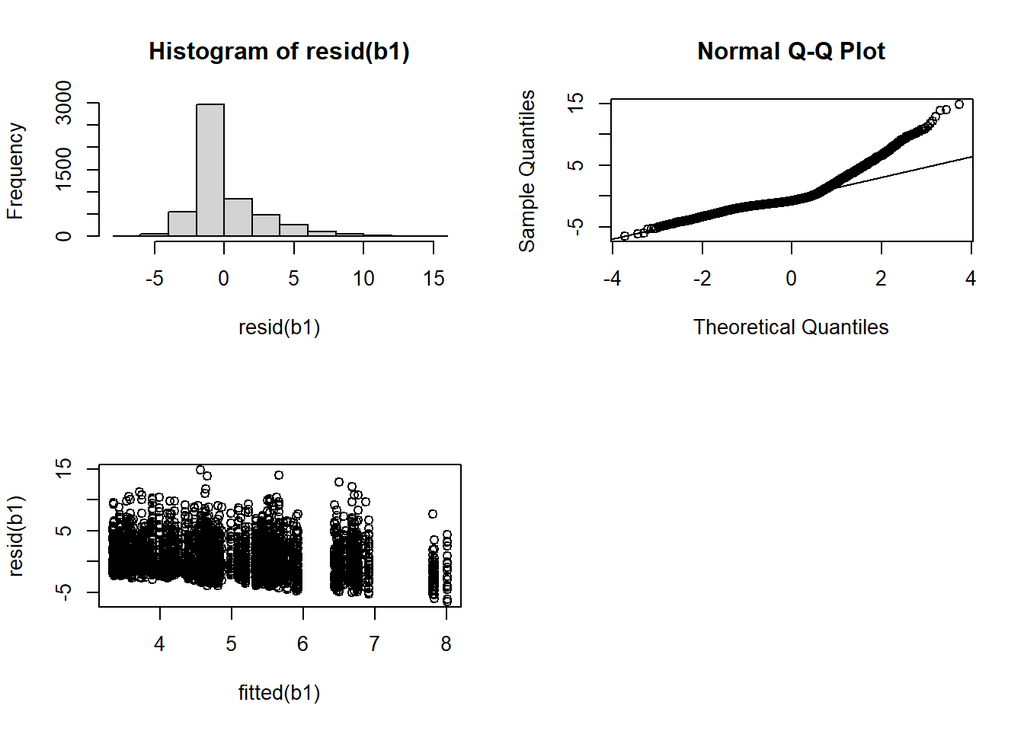

```r
par(mfrow=c(2, 2))
hist(resid(b1))
qqnorm(resid(b1));qqline(resid(b1))
plot(fitted(b1), resid(b1))

par(mfrow=c(2, 2))
```

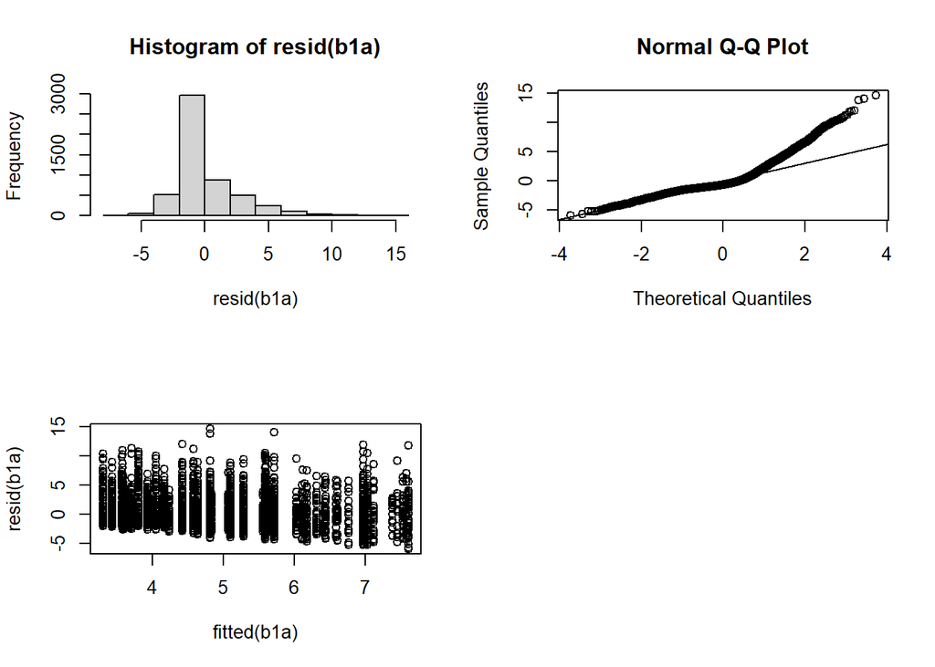

```r
hist(resid(b1a))
qqnorm(resid(b1a));qqline(resid(b1a))
plot(fitted(b1a), resid(b1a))
```

### Inhalation duration

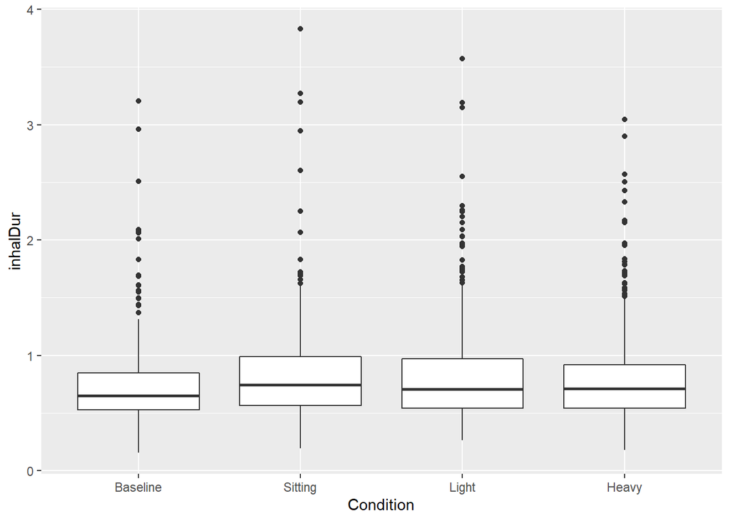

```r
ggplot(dat, aes(Condition, inhalDur))+
  geom_boxplot()+
  scale_x_discrete(limits = orderCondBase)
```

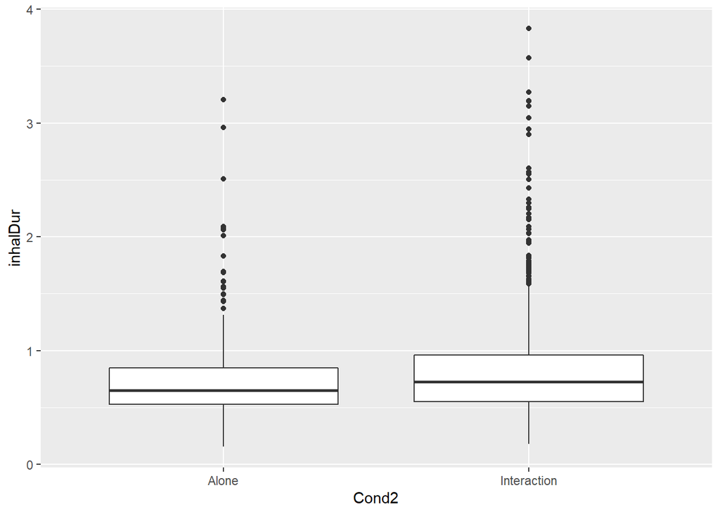

```r
ggplot(dat, aes(Cond2, inhalDur))+
  geom_boxplot()
```

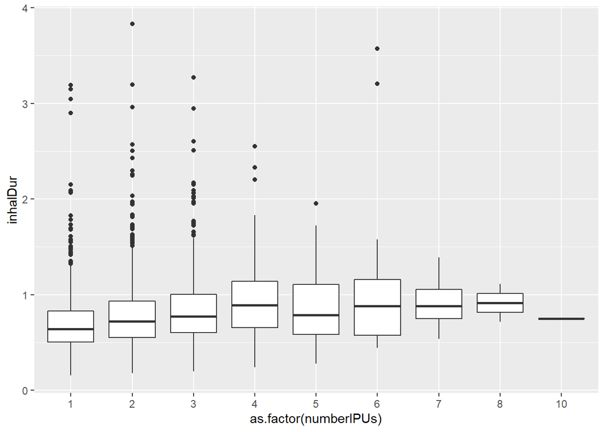

```r
ggplot(dat, aes(as.factor(numberIPUs), inhalDur))+
  geom_boxplot()
```

The number of IPUs in the subsequent exhalation also induces longer inhalations. This effect was bigger than the condition effect. We can relate this to previous findings on speech planning and breathing.

```r
summary(d4 <- lmer(inhalDur ~ numberIPUsC + Cond2 + (1 + Cond2 | Speaker), dat))
```

```
## Linear mixed model fit by REML ['lmerMod']
## Formula: inhalDur ~ numberIPUsC + Cond2 + (1 + Cond2 | Speaker)
##    Data: dat
##
## REML criterion at convergence: 1704.1
##
## Scaled residuals:
##     Min      1Q  Median      3Q     Max
## -2.2321 -0.5821 -0.1654  0.3526  8.7750
##
## Random effects:
##  Groups   Name             Variance Std.Dev. Corr
##  Speaker  (Intercept)      0.006855 0.08279
##           Cond2Interaction 0.007616 0.08727  0.35
##  Residual                  0.120442 0.34705
## Number of obs: 2249, groups:  Speaker, 22
##
## Fixed effects:
##                  Estimate Std. Error t value
## (Intercept)      0.733998   0.023059  31.831
## numberIPUsC      0.066533   0.006891   9.655
## Cond2Interaction 0.096311   0.025405   3.791
##
## Correlation of Fixed Effects:
##             (Intr) nmIPUC
## numberIPUsC -0.010
## Cnd2Intrctn -0.177  0.011
```

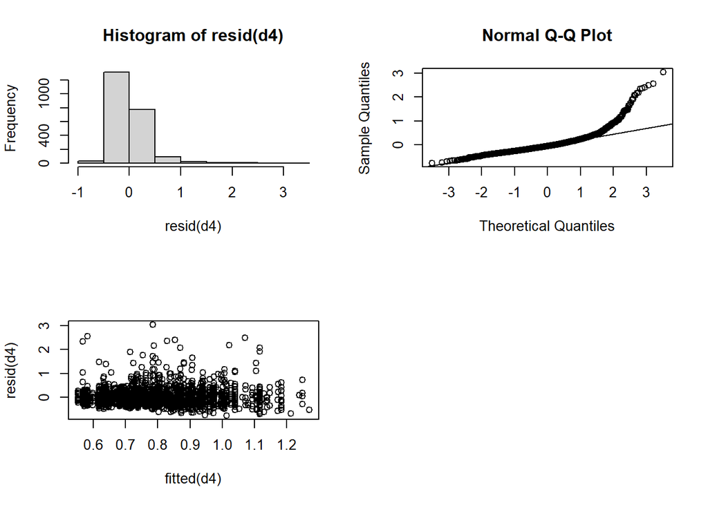

```r
par(mfrow=c(2, 2))
hist(resid(d4))
qqnorm(resid(d4));qqline(resid(d4))
plot(fitted(d4), resid(d4))
```

### Inhalation amplitude

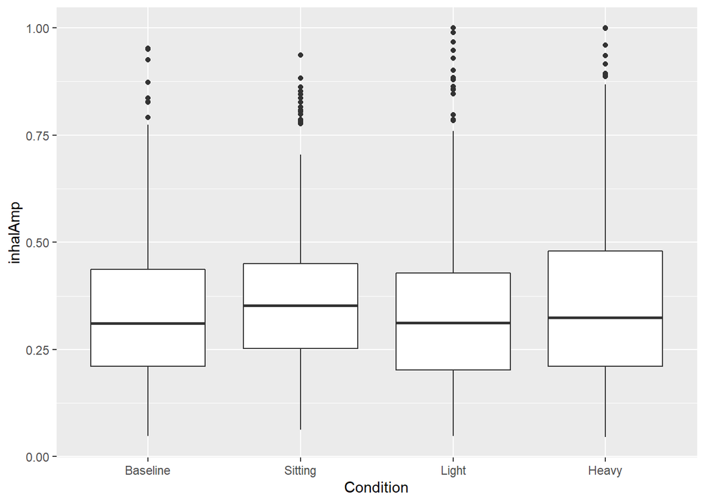

```r
ggplot(dat, aes(Condition, inhalAmp))+
  geom_boxplot()+
  scale_x_discrete(limits = orderCondBase)
```

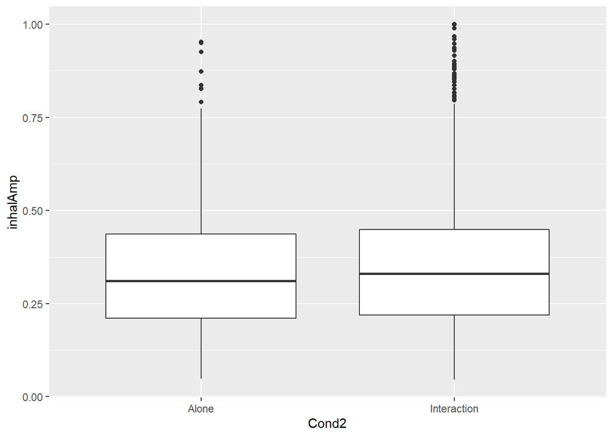

```r
ggplot(dat, aes(Cond2, inhalAmp))+
  geom_boxplot()
```

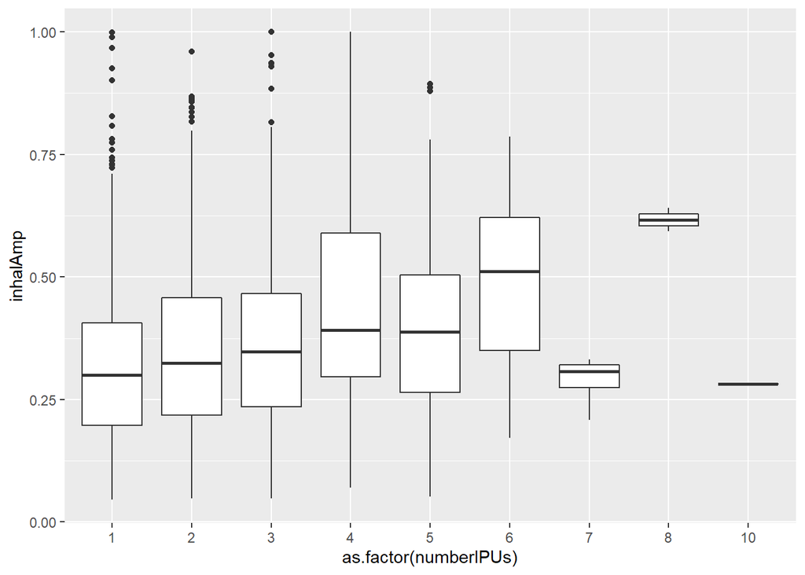

```r
ggplot(dat, aes(as.factor(numberIPUs), inhalAmp))+
  geom_boxplot()
```

No condition effect for inhalation amplitude.

```r
summary(a2 <- lmer(inhalAmp ~ Condition + (1 + Condition| Speaker), dat))
```

```
## Linear mixed model fit by REML ['lmerMod']
## Formula: inhalAmp ~ Condition + (1 + Condition | Speaker)
##    Data: dat
##
## REML criterion at convergence: -1755.7
##
## Scaled residuals:
##     Min      1Q  Median      3Q     Max
## -2.5655 -0.6529 -0.1069  0.5150  4.4689
##
## Random effects:
##  Groups   Name              Variance Std.Dev. Corr
##  Speaker  (Intercept)       0.003117 0.05583
##           ConditionBaseline 0.003455 0.05878  -0.30
##           ConditionLight    0.003671 0.06059  -0.18  0.46
##           ConditionHeavy    0.010680 0.10334  -0.11  0.00  0.54
##  Residual                   0.024953 0.15797
## Number of obs: 2249, groups:  Speaker, 22
##
## Fixed effects:
##                   Estimate Std. Error t value
## (Intercept)        0.36833    0.01374  26.807
## ConditionBaseline -0.02603    0.01587  -1.640
## ConditionLight    -0.01015    0.01635  -0.620
## ConditionHeavy     0.02860    0.02426   1.179
##
## Correlation of Fixed Effects:
##             (Intr) CndtnB CndtnL
## ConditnBsln -0.418
## ConditnLght -0.331  0.468
## ConditinHvy -0.230  0.118  0.507
```

```r
summary(a2 <- lmer(inhalAmp ~ Cond2 + (1 + Cond2| Speaker), dat))
```

```
## Linear mixed model fit by REML ['lmerMod']
## Formula: inhalAmp ~ Cond2 + (1 + Cond2 | Speaker)
##    Data: dat
##
## REML criterion at convergence: -1679.9
##
## Scaled residuals:
##     Min      1Q  Median      3Q     Max
## -2.4863 -0.6819 -0.1358  0.5287  4.2072
##
## Random effects:
##  Groups   Name             Variance Std.Dev. Corr
##  Speaker  (Intercept)      0.004486 0.06698
##           Cond2Interaction 0.003661 0.06051  -0.48
##  Residual                  0.026575 0.16302
## Number of obs: 2249, groups:  Speaker, 22
##
## Fixed effects:
##                  Estimate Std. Error t value
## (Intercept)       0.34134    0.01599  21.351
## Cond2Interaction  0.02727    0.01536   1.776
##
## Correlation of Fixed Effects:
##             (Intr)
## Cnd2Intrctn -0.568
```

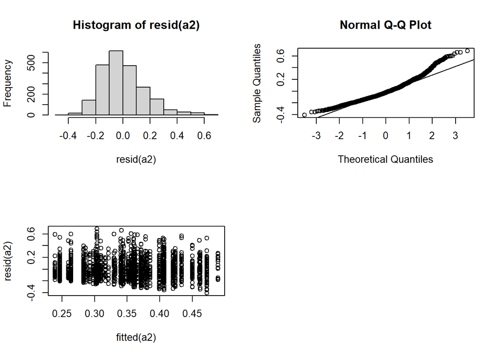

```r
par(mfrow=c(2, 2))
hist(resid(a2))
qqnorm(resid(a2));qqline(resid(a2))
plot(fitted(a2), resid(a2))
```

### Number of IPUs per breath cycle?

We also have some results on the number of IPUs per cycle, but I’m not sure if it’s relevant for us to report. The model is `numberIPUs ~ breathCycle + BMI + InterEnjoy`, where `breathCycle` is how far into the recording it is, `BMI` is body mass index and `InterEnjoy` is the participants’ rating of how much they enjoyed the interaction.

## Confederate

### Breathing rate

The blue points are the actual data points (it’s only three per condition). If we show this graph, I don’t know if boxplots or points are better.

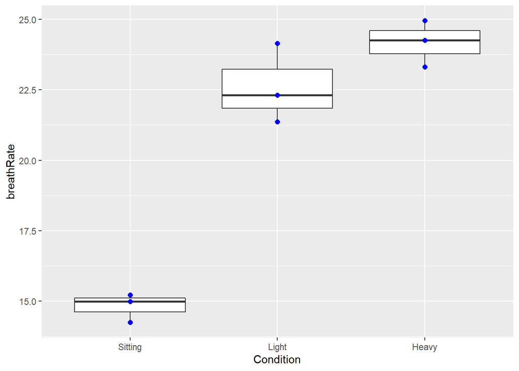

```r
ggplot(dat, aes(Condition, breathRate))+
  geom_boxplot()+
  geom_point(size=2, color="blue")
```

For the confederate, breathing rate increased from sitting to biking (but no significant difference between light and heavy biking).

(We obtain the same results with breath cycle durations.)

```r
dat$Condition <- relevel(dat$Condition, ref="Light")
summary(b1 <- lm(breathRate ~ Condition, dat))
```

```
##
## Call:
## lm(formula = breathRate ~ Condition, data = dat)
##
## Residuals:
##      Min       1Q   Median       3Q      Max
## -1.23951 -0.57779  0.08105  0.40448  1.54311
##
## Coefficients:
##                  Estimate Std. Error t value Pr(>|t|)
## (Intercept)       22.6119     0.5726  39.492 1.76e-08 ***
## ConditionSitting  -7.7920     0.8097  -9.623 7.21e-05 ***
## ConditionHeavy     1.5633     0.8097   1.931    0.102
## ---
## Signif. codes:  0 '***' 0.001 '**' 0.01 '*' 0.05 '.' 0.1 ' ' 1
##
## Residual standard error: 0.9917 on 6 degrees of freedom
## Multiple R-squared:  0.9623, Adjusted R-squared:  0.9498
## F-statistic:  76.6 on 2 and 6 DF,  p-value: 5.353e-05
```

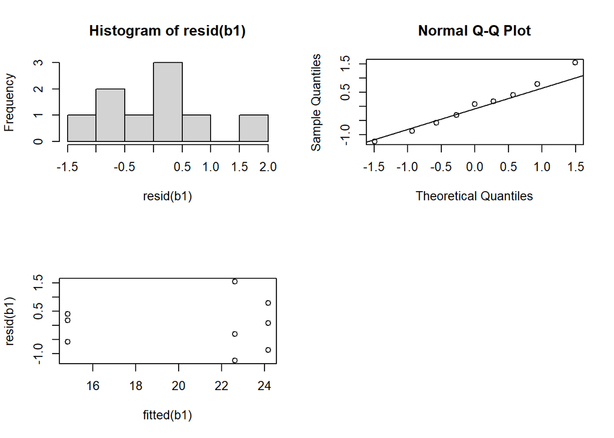

```r
par(mfrow=c(2, 2))
hist(resid(b1))
qqnorm(resid(b1));qqline(resid(b1))
plot(fitted(b1), resid(b1))
```

### Breath cycle duration

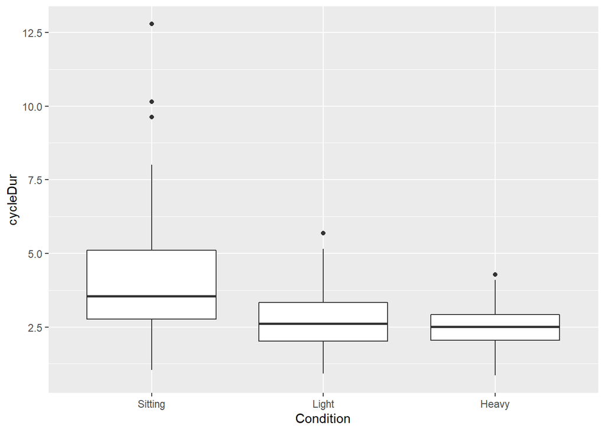

```r
ggplot(dat, aes(Condition, cycleDur))+
  geom_boxplot()+
  scale_x_discrete(limits = orderCond)
```

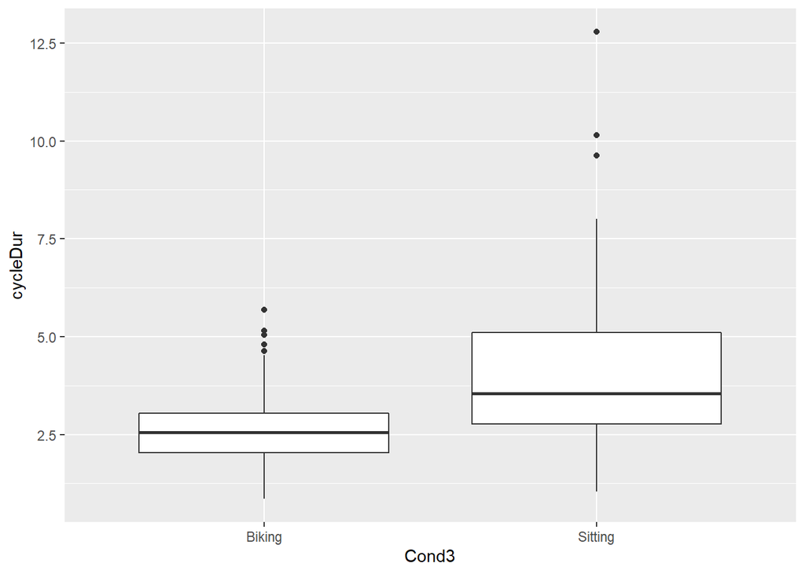

```r
ggplot(dat, aes(Cond3, cycleDur))+
  geom_boxplot()
```

```r
dat$Condition <- relevel(dat$Condition, ref="Light")
summary(b1 <- lm(cycleDur ~ Condition, dat))
```

```
##
## Call:
## lm(formula = cycleDur ~ Condition, data = dat)
##
## Residuals:
##     Min      1Q  Median      3Q     Max
## -3.0089 -0.7171 -0.0978  0.5891  8.7333
##
## Coefficients:
##                  Estimate Std. Error t value Pr(>|t|)
## (Intercept)       2.65808    0.08776  30.288   <2e-16 ***
## ConditionSitting  1.39432    0.13600  10.253   <2e-16 ***
## ConditionHeavy   -0.17487    0.12869  -1.359    0.175
## ---
## Signif. codes:  0 '***' 0.001 '**' 0.01 '*' 0.05 '.' 0.1 ' ' 1
##
## Residual standard error: 1.238 on 511 degrees of freedom
## Multiple R-squared:  0.2244, Adjusted R-squared:  0.2214
## F-statistic: 73.93 on 2 and 511 DF,  p-value: < 2.2e-16
```

```r
summary(b1a <- lm(cycleDur ~ Cond3, dat))
```

```
##
## Call:
## lm(formula = cycleDur ~ Cond3, data = dat)
##
## Residuals:
##     Min      1Q  Median      3Q     Max
## -3.0089 -0.7085 -0.0847  0.5734  8.7333
##
## Coefficients:
##              Estimate Std. Error t value Pr(>|t|)
## (Intercept)   2.57676    0.06424   40.11   <2e-16 ***
## Cond3Sitting  1.47564    0.12222   12.07   <2e-16 ***
## ---
## Signif. codes:  0 '***' 0.001 '**' 0.01 '*' 0.05 '.' 0.1 ' ' 1
##
## Residual standard error: 1.239 on 512 degrees of freedom
## Multiple R-squared:  0.2216, Adjusted R-squared:  0.2201
## F-statistic: 145.8 on 1 and 512 DF,  p-value: < 2.2e-16
```

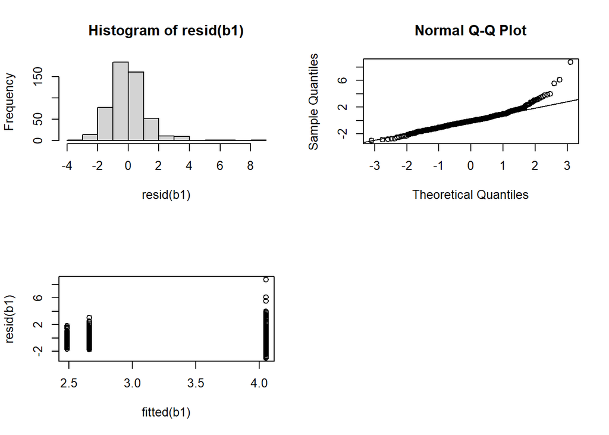

```r
par(mfrow=c(2, 2))
hist(resid(b1))
qqnorm(resid(b1));qqline(resid(b1))
plot(fitted(b1), resid(b1))

par(mfrow=c(2, 2))
```

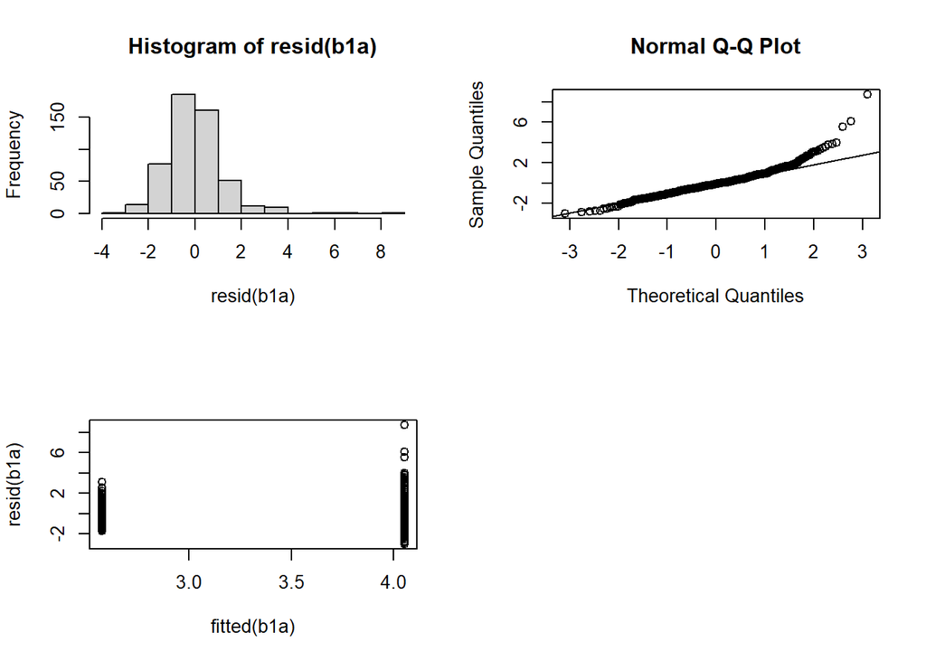

```r
hist(resid(b1a))
qqnorm(resid(b1a));qqline(resid(b1a))
plot(fitted(b1a), resid(b1a))
```

### Inhalation duration

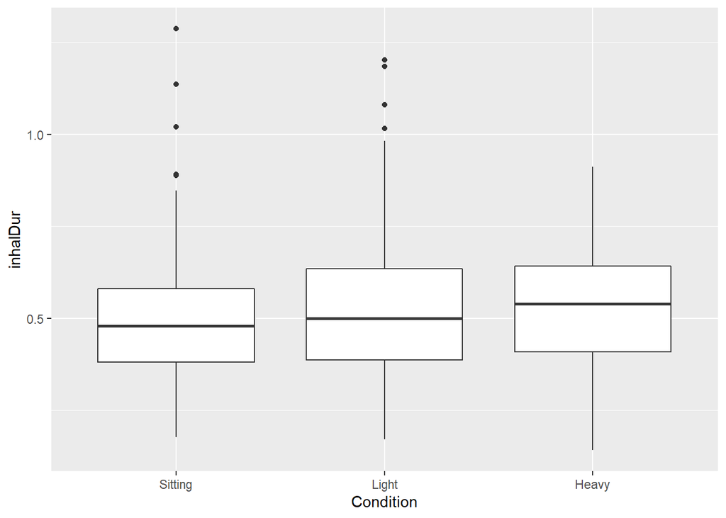

```r
ggplot(dat, aes(Condition, inhalDur))+
  geom_boxplot()+
  scale_x_discrete(limits = orderCond)
```

Inhalation duration doesn’t change across conditions. (Same for `sitting` vs `biking`.)

```r
summary(d1 <- lm(inhalDur ~ Condition, dat))
```

```
##
## Call:
## lm(formula = inhalDur ~ Condition, data = dat)
##
## Residuals:
##      Min       1Q   Median       3Q      Max
## -0.38287 -0.12370 -0.01435  0.10005  0.78708
##
## Coefficients:
##                  Estimate Std. Error t value Pr(>|t|)
## (Intercept)       0.52185    0.01246  41.872   <2e-16 ***
## ConditionSitting -0.02221    0.01931  -1.150    0.251
## ConditionHeavy    0.00230    0.01828   0.126    0.900
## ---
## Signif. codes:  0 '***' 0.001 '**' 0.01 '*' 0.05 '.' 0.1 ' ' 1
##
## Residual standard error: 0.1758 on 511 degrees of freedom
## Multiple R-squared:  0.003544,   Adjusted R-squared:  -0.000356
## F-statistic: 0.9087 on 2 and 511 DF,  p-value: 0.4037
```

### Inhalation amplitude

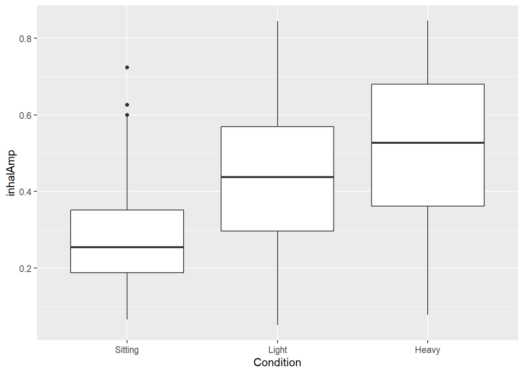

```r
ggplot(dat, aes(Condition, inhalAmp))+
  geom_boxplot()+
  scale_x_discrete(limits = orderCond)
```

Inhalation amplitude gets larger with physical effort. Why the difference between inhalation duration and amplitude? Maybe different people have different strategies for inhaling when they need more oxygen – some people may inhale longer while others “deeper”? Or else, the correlation between amplitude and duration may only be true for people sitting (our participants); when doing exercise + speaking and actually needing more oxygen, people may just inhale “deeper” instead of longer. Just speculation…

```r
summary(d1 <- lm(inhalAmp ~ Condition, dat))
```

```
##
## Call:
## lm(formula = inhalAmp ~ Condition, data = dat)
##
## Residuals:
##      Min       1Q   Median       3Q      Max
## -0.42765 -0.12191 -0.00077  0.13229  0.43873
##
## Coefficients:
##                  Estimate Std. Error t value Pr(>|t|)
## (Intercept)       0.43273    0.01241  34.878  < 2e-16 ***
## ConditionSitting -0.14821    0.01923  -7.709 6.68e-14 ***
## ConditionHeavy    0.07267    0.01819   3.994 7.44e-05 ***
## ---
## Signif. codes:  0 '***' 0.001 '**' 0.01 '*' 0.05 '.' 0.1 ' ' 1
##
## Residual standard error: 0.175 on 511 degrees of freedom
## Multiple R-squared:  0.1992, Adjusted R-squared:  0.196
## F-statistic: 63.54 on 2 and 511 DF,  p-value: < 2.2e-16
```

```r
# ggplot(dat, aes(Condition, as.numeric(numberIPUs)))+
#   geom_violin()
```

```r
# summary(n3 <- MASS::polr(numberIPUs ~ Condition * breathCycle, data=dat, Hess=TRUE))
```

# Speech data: FREE speech

## Participants

### f0

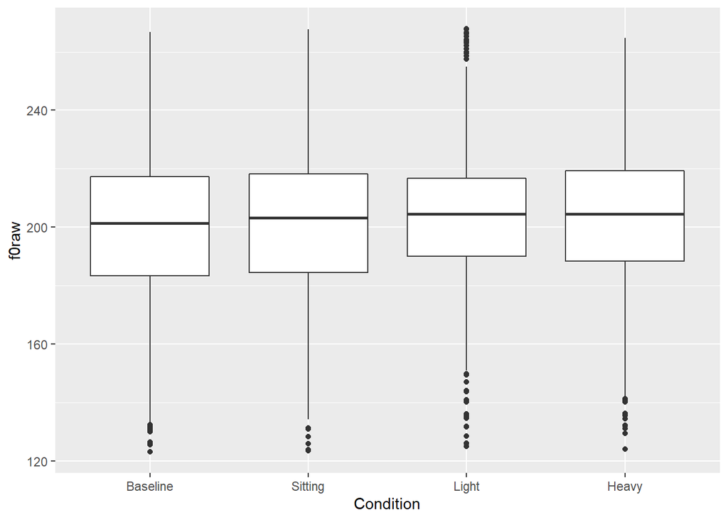

```r
ggplot(df, aes(Condition, f0raw))+
  geom_boxplot()+
  scale_x_discrete(limits = orderCondBase)
```

f0 didn’t change with condition.

```r
summary(m1 <- lmer(f0raw ~ Condition + (1 + Condition | Speaker), df))
```

```
## Linear mixed model fit by REML ['lmerMod']
## Formula: f0raw ~ Condition + (1 + Condition | Speaker)
##    Data: df
##
## REML criterion at convergence: 32153.7
##
## Scaled residuals:
##     Min      1Q  Median      3Q     Max
## -3.4483 -0.6097 -0.0536  0.5756  4.0172
##
## Random effects:
##  Groups   Name              Variance Std.Dev. Corr
##  Speaker  (Intercept)       404.34   20.108
##           ConditionBaseline  95.61    9.778   -0.13
##           ConditionLight     25.61    5.061   -0.54 -0.15
##           ConditionHeavy     19.82    4.452   -0.05 -0.22 -0.36
##  Residual                   349.32   18.690
## Number of obs: 3678, groups:  Speaker, 22
##
## Fixed effects:
##                   Estimate Std. Error t value
## (Intercept)       198.1544     4.3886  45.152
## ConditionBaseline  -1.6707     2.3117  -0.723
## ConditionLight     -0.1279     1.4328  -0.089
## ConditionHeavy      1.0195     1.3355   0.763
##
## Correlation of Fixed Effects:
##             (Intr) CndtnB CndtnL
## ConditnBsln -0.168
## ConditnLght -0.465  0.018
## ConditinHvy -0.103 -0.020 -0.003
```

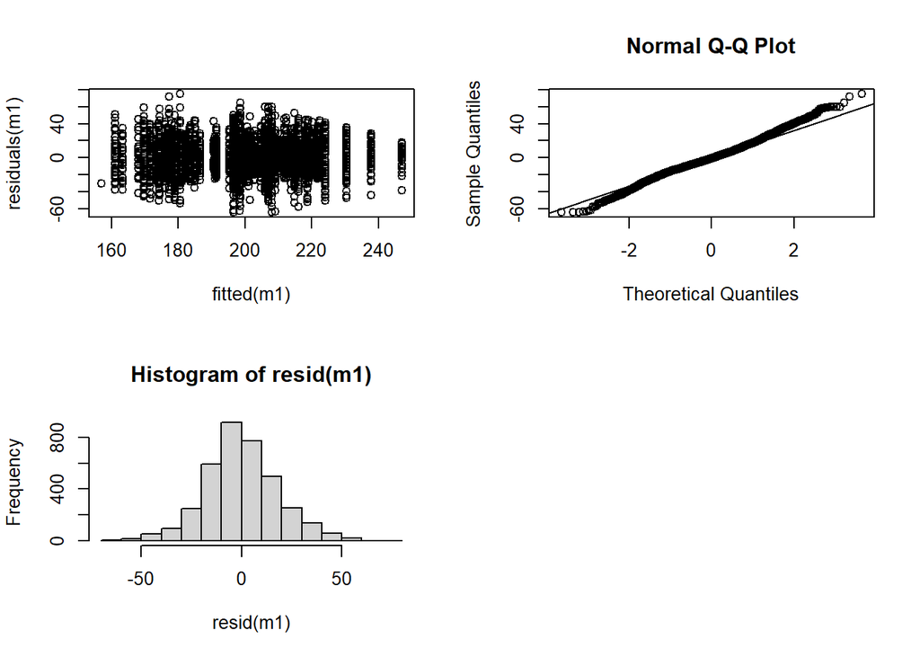

```r
par(mfrow=c(2, 2))
plot(fitted(m1), residuals(m1))
qqnorm(resid(m1));qqline(resid(m1)) # residuals ok I think
hist(resid(m1))
```

### Articulation Rate

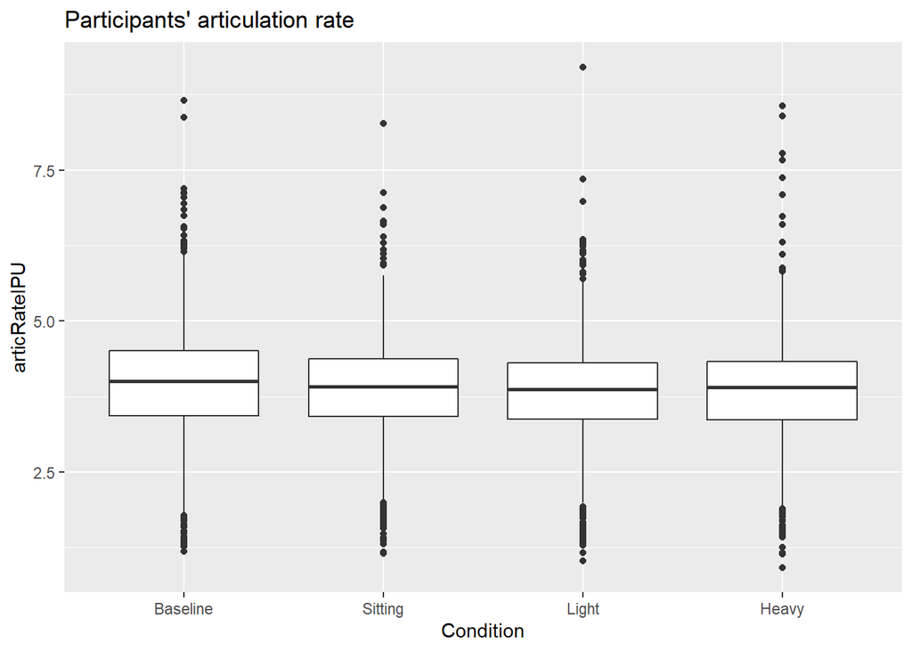

```r
ggplot(df, aes(Condition, articRateIPU))+
  geom_boxplot()+
  scale_x_discrete(limits = orderCondBase)+
  ggtitle("Participants' articulation rate")
```

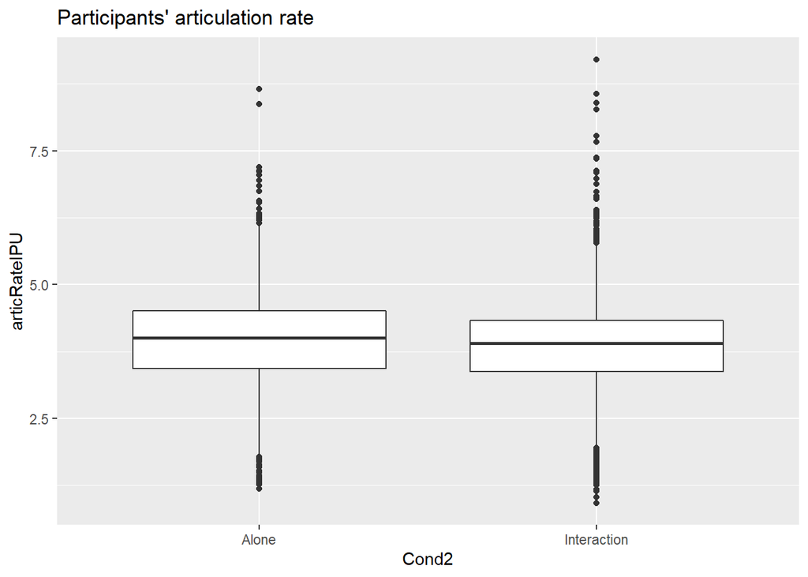

```r
ggplot(df, aes(Cond2, articRateIPU))+
  geom_boxplot()+
  ggtitle("Participants' articulation rate")
```

With articulation rate as the dependent variable, people seem to speak slower during the experimental conditions (the interaction with the confederate) as compared to the baseline (speaking by themselves).

```r
summary(s5 <- lmer(articRateIPU ~ Condition + (1  | Speaker),  df))
```

```
## Linear mixed model fit by REML ['lmerMod']
## Formula: articRateIPU ~ Condition + (1 | Speaker)
##    Data: df
##
## REML criterion at convergence: 11136.5
##
## Scaled residuals:
##     Min      1Q  Median      3Q     Max
## -3.4409 -0.4988  0.0732  0.5779  5.9270
##
## Random effects:
##  Groups   Name        Variance Std.Dev.
##  Speaker  (Intercept) 0.01777  0.1333
##  Residual             0.77276  0.8791
## Number of obs: 4296, groups:  Speaker, 22
##
## Fixed effects:
##                   Estimate Std. Error t value
## (Intercept)        3.80958    0.03963  96.139
## ConditionBaseline  0.13860    0.03809   3.639
## ConditionSitting   0.05330    0.03822   1.394
## ConditionHeavy     0.01601    0.03898   0.411
##
## Correlation of Fixed Effects:
##             (Intr) CndtnB CndtnS
## ConditnBsln -0.501
## CondtnSttng -0.493  0.514
## ConditinHvy -0.479  0.500  0.500
```

```r
summary(s5a <- lmer(articRateIPU ~ Cond2 + (1 + Cond2 | Speaker),  df))
```

```
## Linear mixed model fit by REML ['lmerMod']
## Formula: articRateIPU ~ Cond2 + (1 + Cond2 | Speaker)
##    Data: df
##
## REML criterion at convergence: 11124.5
##
## Scaled residuals:
##     Min      1Q  Median      3Q     Max
## -3.4267 -0.4974  0.0746  0.5806  5.8798
##
## Random effects:
##  Groups   Name             Variance Std.Dev. Corr
##  Speaker  (Intercept)      0.01579  0.1256
##           Cond2Interaction 0.01278  0.1130   -0.25
##  Residual                  0.77043  0.8777
## Number of obs: 4296, groups:  Speaker, 22
##
## Fixed effects:
##                  Estimate Std. Error t value
## (Intercept)       3.94793    0.03783 104.371
## Cond2Interaction -0.11505    0.03949  -2.913
##
## Correlation of Fixed Effects:
##             (Intr)
## Cnd2Intrctn -0.585
```

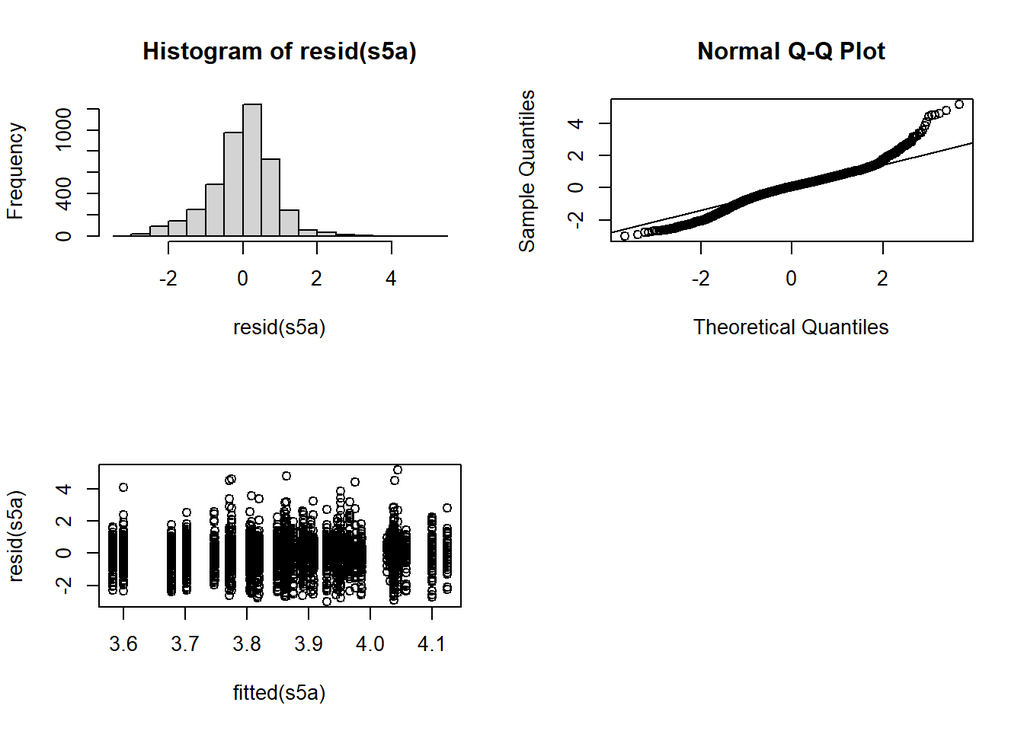

```r
par(mfrow=c(2, 2))
hist(resid(s5a))
qqnorm(resid(s5a));qqline(resid(s5a))
plot(fitted(s5a), resid(s5a))
```

## Confederate

### f0

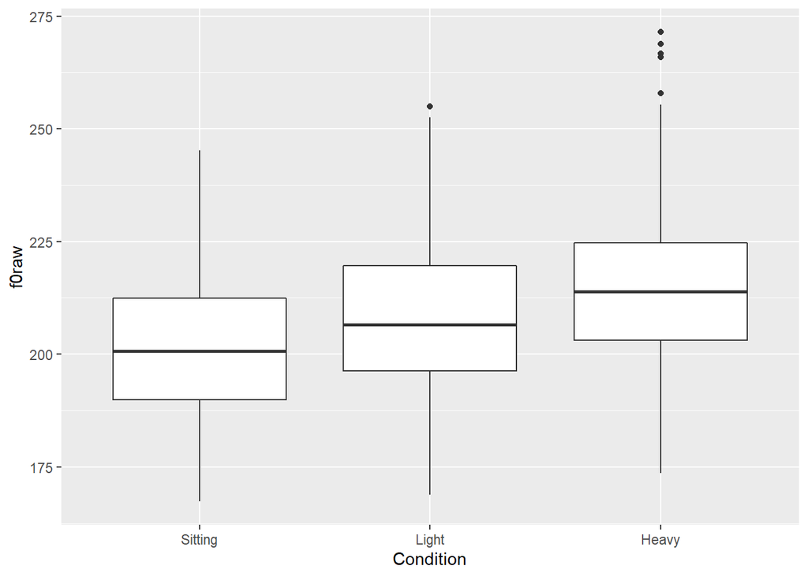

```r
ggplot(df, aes(Condition, f0raw))+
  geom_boxplot()+
  scale_x_discrete(limits = orderCond)
```

f0 got consistently higher with physical effort.

```r
summary(m1 <- lm(f0raw ~ Condition, df))
```

```
##
## Call:
## lm(formula = f0raw ~ Condition, data = df)
##
## Residuals:
##     Min      1Q  Median      3Q     Max
## -40.832 -11.885  -1.332  10.613  57.018
##
## Coefficients:
##                  Estimate Std. Error t value Pr(>|t|)
## (Intercept)      208.4600     0.9929 209.943  < 2e-16 ***
## ConditionHeavy     5.9720     1.4558   4.102 4.50e-05 ***
## ConditionSitting  -6.4084     1.4284  -4.486 8.29e-06 ***
## ---
## Signif. codes:  0 '***' 0.001 '**' 0.01 '*' 0.05 '.' 0.1 ' ' 1
##
## Residual standard error: 16.97 on 816 degrees of freedom
##   (68 observations deleted due to missingness)
## Multiple R-squared:  0.07919,    Adjusted R-squared:  0.07694
## F-statistic: 35.09 on 2 and 816 DF,  p-value: 2.402e-15
```

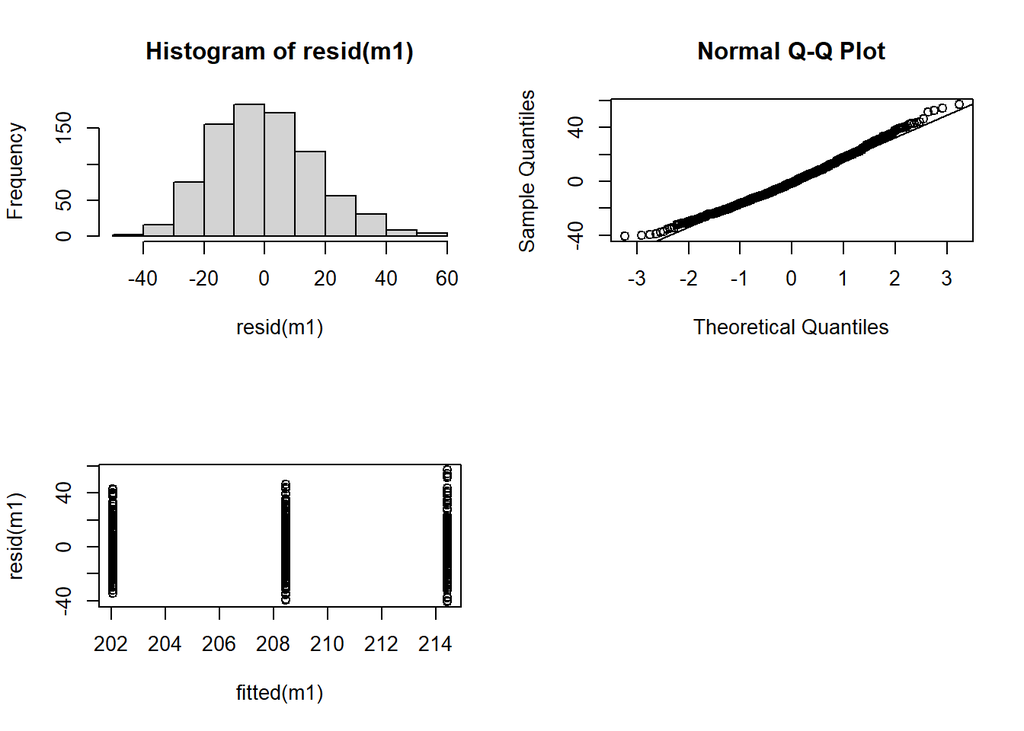

```r
par(mfrow=c(2, 2))
hist(resid(m1))
qqnorm(resid(m1));qqline(resid(m1))
plot(fitted(m1), resid(m1))
```